# Scheduling Luck

Alexandra Kelly

2022-12-7

# Scheduling Luck

There’s been some chatter about discrepancies in points for among league leaders at this point in the season. Is it possible that some among our top playoff contenders have benefitted from luck of the draw when it comes to their schedule, playing worse-performing managers on a regular basis?

It’s hard to actually quantify how much your opponent’s performance every week contributes to your record separately from all of the other factors, but this is what I came up with last year to prove that Kevin was a fraudulent league leader.

We take a manager (we’ll use bbopski only because his name is first alphabetically), and we see how they would have done against every other manager in a head-to-head matchup for each week:

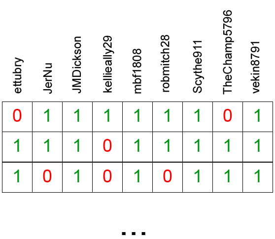

and so on, for all 13 weeks. You get the idea. Then we sum all of the wins they would have had against the field, and take the average to derive an *expected number of wins*:

$$\frac{{\Sigma}VictoriesAgainstEachManager}{NumberOfOtherManagers} =
ExpectedWins$$

By comparing this expected number of wins to their actual number of wins, we can see how much each manager has benefitted from or been hurt by scheduling.

| manager | expected_wins | actual_wins | difference |
| --- | --- | --- | --- |
| bbposki | 8.67 | 9 | 0.33 |
| ettubry | 5.11 | 4 | -1.11 |
| JerNu | 7.22 | 11 | 3.78 |
| JMDickson | 5.56 | 4 | -1.56 |
| kellieally | 8.56 | 8 | -0.56 |
| mbf1808 | 6.89 | 6 | -0.89 |
| robmitch28 | 4.89 | 7 | 2.11 |
| Scythe911 | 8.00 | 6 | -2 |
| TheChamp5796 | 5.00 | 5 | 0 |
| vekin8791 | 5.11 | 5 | -0.11 |

I’ve highlighted teams who have >/< 1 win more than they should. Our lucky ducks are Jerick (who as Bill noted earlier should be ~.500; hard to evaluate Jerick’s argument that other manager’s players underperform against him with just these numbers, but…just keep that in mind I guess), and Rob.

We do have some managers who seem to have gotten the shaft with their schedules too - ettubry should have about 1 more win. As much as it pains both us and him to hear it, Scythe911 would be expected to have 2 more wins to his name, and Jared is approaching the same (so I guess he’s right - his team is stronger than any of us think?).

Shoutout to mbf1808 who is approaching but didn’t quite reach my completely arbitrary cutoff, but seems to have been slightly unlucky.